# JUb19 versus CEN2ent

Based on May 7th Discussion, JUb19 and CEN2ent became a main interest, and we now conducted the competition experiment under different initial frequencies. This allowed us to estimate competition coefficients via a different approach; thus, we give it a separate treatment here.

# Data formating from pairwise competition

Compile data from different competition assays (JUb19 as donor and CEN2ent species as recipient) at start (0 hr) and end (24 hr) points (under OD = 1).

| strain | replicate | D0 | R0 | logD0 | logR0 | D24 | R24 | logD24 | logR24 | ratio |
| --- | --- | --- | --- | --- | --- | --- | --- | --- | --- | --- |
| CEN2ent | 1 | 1.22e+10 | 2.40e+09 | 10.086360 | 9.380211 | 1.80e+12 | 1.28e+12 | 12.25527 | 12.10721 | 5:5 |
| CEN2ent | 2 | 9.90e+09 | 3.60e+09 | 9.995635 | 9.556303 | 2.24e+12 | 1.24e+12 | 12.35025 | 12.09342 | 5:5 |
| CEN2ent | 3 | 1.10e+10 | 3.10e+09 | 10.041393 | 9.491362 | 1.92e+12 | 9.60e+11 | 12.28330 | 11.98227 | 5:5 |
| CEN2ent | 4 | 9.20e+09 | 4.80e+09 | 9.963788 | 9.681241 | 1.76e+12 | 1.00e+12 | 12.24551 | 12.00000 | 5:5 |
| CEN2ent | 5 | 9.80e+09 | 4.60e+09 | 9.991226 | 9.662758 | 2.08e+12 | 8.80e+11 | 12.31806 | 11.94448 | 5:5 |
| CEN2ent | 6 | 8.70e+09 | 5.10e+09 | 9.939519 | 9.707570 | 1.20e+12 | 1.00e+12 | 12.07918 | 12.00000 | 5:5 |
| CEN2ent | 1 | 2.05e+09 | 9.50e+09 | 9.311754 | 9.977724 | 2.52e+11 | 5.36e+11 | 11.40140 | 11.72916 | 1:9 |
| CEN2ent | 2 | 2.22e+09 | 8.40e+09 | 9.346353 | 9.924279 | 1.44e+11 | 6.08e+11 | 11.15836 | 11.78390 | 1:9 |
| CEN2ent | 3 | 1.99e+09 | 1.01e+10 | 9.298853 | 10.004321 | 2.08e+11 | 5.64e+11 | 11.31806 | 11.75128 | 1:9 |
| CEN2ent | 1 | 2.23e+10 | 1.14e+09 | 10.348305 | 9.056905 | 3.00e+12 | 2.68e+11 | 12.47712 | 11.42813 | 9:1 |

[output cut: 2 more lines]

# Frequency lineplot (JUb19 vs CEN2ent)

Here, as a first attempt to visualize the competitive outcome, we plot the frequency change across 0 and 24 hrs. The first figure shows the frequency change for JUb19 (donor) and the second mirrored figure shows that for CEN2ent (recipient). Overall, there’s a signature of species coexistence: the rare species increase in frequency whereas the abundant species decreases in frequency.

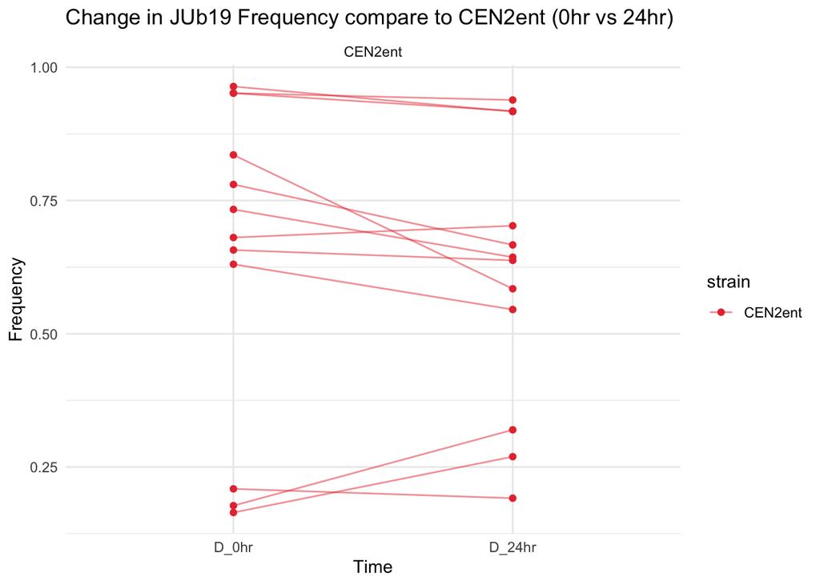

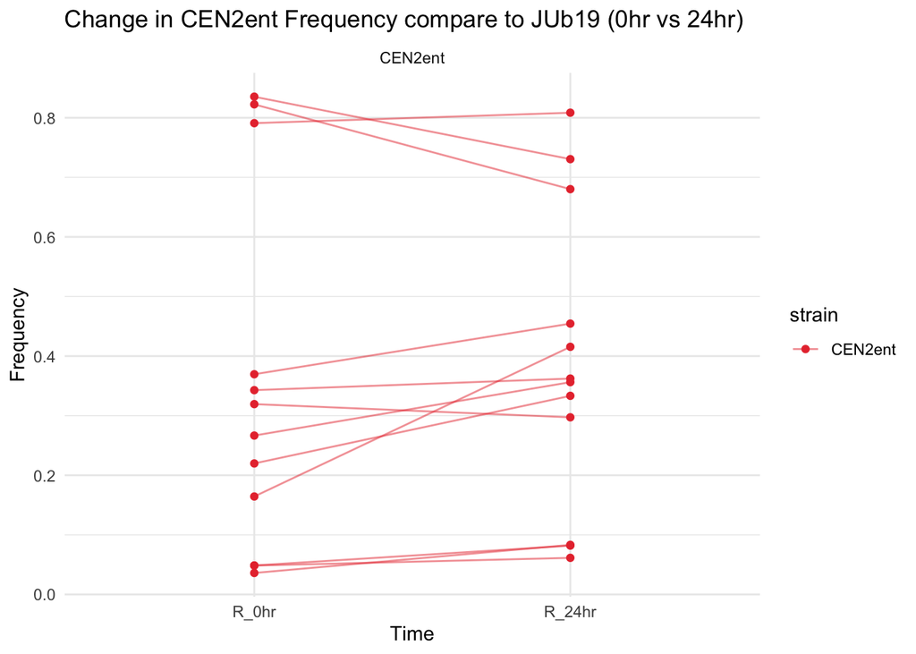

# Interspecies coefficient alpha (JUb19 vs CEN2ent)

Again, consider a Lotkta–Volterra competition model in the form of $\frac{dN_i}{dt} = N_i(r_i-\alpha_{ii}N_i-\alpha_{ij}N_j)$. Previously, we estimated the interspecific competition coefficients ($\alpha_{ij}$) by rearranging the growth expression. That is:
$$\alpha_{ij} =
\left[\hat{r_i}-\hat{\alpha_{ii}}N_{i0}^c-\left(\frac{lnN_{i24}^c -
lnN_{i0}^c}{24})\right)\right].\left(\frac{1}{N_{j0}^c}\right)$$
Here, however, since we have a large initial density gradient for the competition between JUb19 and CEN2ent, we can apply the same statistical fitting approach used to obtained the intraspecific competition coefficients. We did this is a “sequential” approach: the response variable is the difference between the observed per capita growth rate ($\frac{\Delta lnN_i}{\Delta t}$) and the intraspecific competitive impact (i.e., $\hat{r_i}-\hat{\alpha_{ii}}N_{i0}^c$), termed the “residual” in the following figures. This residual term is modeled as a function of the initial heterospecific competitor density ($N_{j0}^c$), and the resulting slope represents the interspecific competition coefficient. Note again all density data were scaled by $10^9$ prior to calculation. Below, we show (left) the estimated effect of CEN2ent on JUb19 ($\alpha_{\textrm{JUb19, CEN2ent}}$), and (right) the estimated effect of JUb19 on CEN2ent ($\alpha_{\textrm{CEN2ent, JUb19}}$). A more detailed comparison of this approach and the previous one, as well as the simulated over competitive outcome, will follow soon.

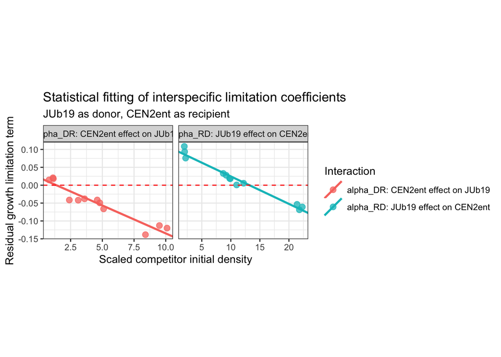